# Monte Carlo :

**Bertrand PATUREL & Omar El Mellouki**

**Professeur Pierre Gloaguen**

Cours ENSTA : https://papayoun.github.io/courses/2020_monte_carlo/

Dans ce problème on souhaite savoir si à partir d'un vecteur d'observations $X_{1:n}=(X_1,..,X_n)$ il existe une suite d'observations (noté $S(i,j)=\sum_{k=i}^j{R_k}$) anormalement élevées. Nous testons donc l'hypothèse $H_0$ : le vecteur est i.i.d. contre $H_1$ il existe une fenêtre de valeur anormalement élevées.

## Calcul des probabilités sous l'hypothèse $H_0$.

Soit $k$ un en entier naturel compris entre 1 et n. $R_k$ est le rang de $X_k$ cela signifie que $X_k$ est plus grand que $R_k-1$ variable(s) aléatoire(s) du vecteur $X_{1:n}$. Donc $R_k=\sum_1^n\mathbb{1} _{X_k \geq X_i}$. Or pour chaque $i$ différent de $k$, $\mathbb{1} _{X_k \geq X_i}$ suit une loi de bernouilli de paramètre $p=\frac{1}{2}$, puisque l'on a autant de chance d'obtenir $X_k \geq X_i$ que son évènement complémentaire. La variable $R_k-\mathbb{1} _{X_k \geq X_i}$ somme de $n-1$ variables indépendantes de Bernouilli de paramètre $p=\frac{1}{2}$ suit une loi binomiale $\mathbb{B}(n-1,\frac{1}{2})$, donc une loi uniforme sur {0,..,n-1}. Puisque l'on rajoute $1=\mathbb{1} _{X_k \geq X_i}$ à la variable $R_k-\mathbb{1} _{X_k \geq X_i}=\sum_{i=1, i \ne k}^n\mathbb{1} _{X_k \geq X_i}$, $R_k$ suit alors une loi uniforme sur {1,...,n}.

Soit $(i,j)$ couple d'entiers naturels telque $i\ne j$ compris entre 1 et n. Alors on souhaite calculer $\mathbb{P}(R_k=i | R_l=j)=\frac{\mathbb{P}(R_k=i\cap R_l=j)}{\mathbb{P}(R_l=j)}$ :

- $\mathbb{P}(R_k=i\cap R_l=j)$ est en combinatoire "la probabilité de placer $X_k$ en i ème position (dans la ième case) ou il y a $n$ choix de positions (i.e. de cases), puis de placer $X_l$ en jème poisition (dans la jème case) ou il y a $n-1$ choix de positions restantes (i.e. de cases restantes)". On a donc une probabilité de $\mathbb{P}(R_k=i\cap R_l=j)=\frac{1}{n(n-1)}$.
- $\mathbb{P}(R_l=j)$ est en combinatoire "la probabilité de placer $X_l$ en j ème position (dans la jème case) parmis les $n$ choix de positions (i.e. de cases)". On a donc une probabilité de $\mathbb{P}(R_l=j)=\frac{1}{n}$.
- $\mathbb{P}(R_k=i | R_l=j)$ est en combinatoire "la probabilité de placer $X_k$ en i ème position (dans la ième case) sachant que $X_l$ est deja en jème position (dans la jème case)", il reste donc $n-1$ choix de positions (i.e. de cases) pour placer la variable $X_k$. On a donc une probabilité de $\mathbb{P}(R_k=i | R_l=j)=\frac{1}{n-1}$.

**Donc $\mathbb{P}(R_k=i | R_l=j)=\frac{1}{n-1}$**.

$S(i,j)$ est une fenêtre temporelle des rangs des variables comprises entre $X_i$ et $X_j$ incluses. Cette variable aléatoire est naturellement définit par la somme des rangs inclus dans cette fenêtre. $S(i,j)$ va nous permettre de détecter les plages de valeurs anormalement élevées (si elles existent) du vecteur $X_{1:n}$. Pour ce faire nous allons la comparer à sa valeur de référence (sa moyenne) et étudier son écart type (en calculant sa variance).

Soit $(i,j)$ un couple d'entier entre 1 et n.

Par définition : $\mathbb{E}[S(i,j)]=\mathbb{E}[\sum_{k=i}^j{R_k}]$

Par linéarité : $\mathbb{E}[S(i,j)]=\sum_{k=i}^j\mathbb{E}[{R_k}] = (j-i+1)\mathbb{E}[R_1] = \frac{(j-i+1)(n+1)}{2}$ puisque l'espérance de la variable aléatoire $R_1$ est celle de la loi uniforme sur {1,..,n} : $\mathbb{E}[R_k]=\mathbb{E}[R_1]=\frac{n+1}{2}$

Soit $(i,j)$ un couple d'entier entre 1 et n.

Par définition : $\mathbb{V}[S(i,j)]=\mathbb{V}[\sum_{k=i}^j{R_k}]$

Commencons par calculer la variance de $R_1$ qui correspond à celle de toutes les variables $R_k$ suivant la même loi : $\mathbb{V}[R_1]=\mathbb{E}[R_1^2]-\mathbb{E}[R_1]^2=\sum_{l=1}^n l^2 \mathbb{P}(R_1=l)-\frac{(n+1)^2}{4}=\frac{\sum_{l=1}^n l^2}{n}-\frac{(n+1)^2}{4}=\frac{2n^2+3n+1}{6}-\frac{(n+1)^2}{4}=\frac{n^2-1}{12}=\frac{(n-1)(n+1)}{12}$

Nous pouvons aussi calculer la covariance de $R_1$ et $R_2$ qui est correspond à celle de tous les couple $R_k$ et $R_l$ : $\mathbb{Cov}(R_k,R_l)=\mathbb{Cov}(R_1,R_2)=\mathbb{E}[R_1R_2]-\mathbb{E}[R_1]\mathbb{E}[R_2]=\mathbb{E}[R_1R_2]-\frac{(n+1)^2}{4}=\sum_{1 \le p \ne l \le n}lp\mathbb{P}(R_1R_2=lp)-\frac{(n+1)^2}{4}=2\sum_{1 \le p < l \le n}lp\mathbb{P}(R_1=p\cap R_2=l)-\frac{(n+1)^2}{4}=2\sum_{1 \le p < l \le n}lp\frac{1}{n(n-1)}-\frac{(n+1)^2}{4}=2\sum_{1 \le p < l \le n}lp\frac{1}{n(n-1)}-\frac{(n+1)^2}{4}=2\frac{1}{n(n-1)}\sum_{1 \le p \le n}\sum_{p+1 \le l \le n}lp-\frac{(n+1)^2}{4}=2\frac{1}{n(n-1)}\sum_{1 \le p \le n}l\sum_{p+1 \le l \le n}p-\frac{(n+1)^2}{4}=2\frac{1}{n(n-1)}\sum_{1 \le p \le n}l(\frac{n(n+1)}{2}+\frac{l(l+1)}{2})-\frac{(n+1)^2}{4}=[2\frac{1}{n(n-1)}(\sum_{1 \le p \le n}\frac{-l^2}{2}+\frac{-(l+1)^2}{2})+(\frac{n(n+1)}{2})^2]-[\frac{(n+1)^2}{4}]=[\frac{3n^2+5n+2}{12}]-[\frac{3n^2+6n+3}{12}]=\frac{-n-1}{12}$

Par propriété de la variance : $\mathbb{V}[S(i,j)]=[\sum_{k=i}^j\mathbb{V}[{R_k}]]+[2\sum_{i \le p < l \le j}\mathbb{Cov}(R_p,R_l)]=[\sum_{k=i}^j\mathbb{V}[{R_k}]]+[2\sum_{i \le p < l \le j}\mathbb{Cov}(R_1,R_2)]=[(j-i+1)(\mathbb{V}[R_1])]+[(j-i+1)(j-i)(\mathbb{Cov}(R_1,R_2))]=[(j-i+1)(\frac{(n-1)(n+1)}{12})]+[(j-i+1)(j-i)(\frac{-n-1}{12})]=\frac{j-i+1}{12}((n+1)(n-1)+(n+1)(i-j))=\frac{j-i+1}{12}(n+1)(n+i-j-1)$

## Choisir entre les deux hypothèses par Monte Carlo.

Pour simuler $T_n$ sous $H_0$, on va générer une réalisation de n variables aléatoires i.i.d. Leur loi n'est pas importante, tant qu'ils sont i.i.d, et on sait que la variable aléatoire $R_k$ va dans tout les cas suivre une loi uniforme sur $[1:n]$. On va ensuite calculer la matrice triangulaire des $S(i,j)$, puis celle des $T(i,j)$ à l'aide des expressions de $m_{ij}$ et $v_{ij}$, en faisant attention à bien remplacer la valeur de $T(1,n)$ par 0. On retrouve finalement la valeur maximale de la matrice $T$, qui va correspondre à la valeur simulée de notre statistique.

On souhaite déterminer le quantile $q_{1-\alpha}$ de la loi de $T_n(X)$ sous l'hypothèse $H_0$.

Ensuite nous comparons le quantile trouvé à $t*$ notre statistique obtenue sur le jeu de donnée, si $t*$ est supérieur au quantile, alors on rejette l'hypotèse $H_0$.

## Implémentation du code sur un jeu de données à tester.

```r
hobart <- read.table("https://papayoun.github.io/courses/2020_monte_carlo/enonces_td/hobart.txt
",sep = ";", header = TRUE)# On importe le jeu de données des températures de Hobart

hobart = hobart$mean_january_temperature

get_tn = function(X,a=0){

    n = length(X)

    #Le vecteur des Rk
    R = order(X,decreasing= T)

    #La matrice T(i,j)
    T_ = matrix(data = 0,nrow = n,ncol=n)
    for(j in 1:n){
      for(i in 1:j){
        if (i!=1 & j!=n){
        T_[i,j] = (sum(R[i:j]) - (n+1)*(j - i +1)/2)/sqrt(((1/12)*(n+1)*(j - i+1)*(n - j+i - 1)))
          }
        }
    }

    #Le cas limite
    T_[1,n] = 0

    #Le résultat avec le max et les indices
    res = list(max(T_),which(T_ == max(T_), arr.ind = TRUE))

    #On renvoie la valeur maximale t* et si a vaut 1 on renvoie l'emplacement
    if(a == 1){return(res)}
    if(a == 0){return(max(T_))}


}

(t_star=get_tn(hobart)) #On affiche t*
```

3.93283106029876

```r
get_ho_sample = function(n,M){
  res = c(1:M)
  for(a in 1:M){

    #Le vecteur des Xk
    X = rnorm(n,0,1)

    res[a] = get_tn(X,0)
  }
  return(res)
}
get_ho_sample(50,100) #On affiche notre sample de Tn pour 100 valeurs générées de Tn.
```

[output not shown]

## Calcul de l'estimation de la p value

0.0088

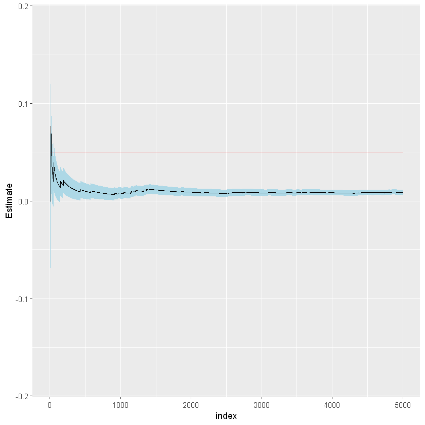

```r
set.seed(123)
n = length(hobart)

sample_hobart = get_ho_sample(n,5000)

#Fonction indicatrice(Tn>t*)

indicatrice = function(x){
  value = 0
  if(x>t_star){value = 1}
  return(value)
}

#Monte Carlo pour le calcul de E(indicatrice(Tn>t*))

indicatrice_Tn = lapply(sample_hobart,indicatrice)


I_hat <- mean(unlist(indicatrice_Tn)) # Estimateur de Monte Carlo de la proba
gamma2_hat <- var(unlist(indicatrice_Tn)) # Variance de Monte Carlo de la proba
z_975 <- qnorm(0.975, 0, 1) # Quantile à 0.975 de la loi normale centrée réduite
IC = I_hat + z_975 * sqrt(gamma2_hat / 5000) * c(-1, 1) #Intervalle de confiance


### On affiche finalement l'intervalle de confiance à 95 %
library(ggplot2)
library(dplyr)

alpha=0.05 #risque de première espèce
my_samples = tibble(index = 1:5000, sample = unlist(indicatrice_Tn))
my_samples %>%
  mutate(Estimate = cumsum(sample) / index,
         IC_95_inf = Estimate - z_975 * sqrt(gamma2_hat / index),
         IC_95_sup = Estimate + z_975 * sqrt(gamma2_hat / index)) %>%
  ggplot(aes(x = index)) +
  geom_ribbon(aes(ymin = IC_95_inf, ymax = IC_95_sup),
              fill = "lightblue") +
  geom_line(aes(y = Estimate)) +
  geom_line(aes(y = alpha),color='red')#le risque de première espèce est en rouge
  labs(x = "M", title = "Estimation Monte Carlo de I",
       y = expression(hat(I)[M])) +
  theme_bw()

I_hat#Voici la p-value approchée, elle est inférieur au seuil alpha
```

## Q10

```r
#On génère un vecteur contenant 5000 réalisations de Tn sous H0 de longueur n égale à celle de Hobart
vect = get_ho_sample(100,5000)
#On calcule son quantile ) 0.95
quantile(vect,0.95) # Voici le quantile à 95%
t_star #Voici la statistique t*
```

**95%:** 3.49721352060894

3.93283106029876

On voit donc bien que le quantile est plus faible que la statistique $t*$ observée sur le jeu de données. On rejette donc $H_0$. Nous pouvions déjà rejeter $H_0$ en question 9 puisque la p-value (égale à environ 0.0088) est plus faible que $\alpha = 0.05$. Ainsi le jeu de données contient une fênetre de valeurs anormalement élevées.

## Remerciements

Ce problème nous a été donné par Mr Pierre Gloaguen à l'ENSTA Paris : https://papayoun.github.io/courses/2020_monte_carlo/ .